# final_project_part03

I-Ling Yeh

2020/10/26

## Load packages

```r
library(tidyverse)
```

```r
library(dplyr)
library(ggplot2)
library(visdat)
library(corrplot)
library(caret)
```

## Overview

This RMarkdown is machine learning final project part 3. Train, tune, and compare binary classifiers Option B via resampling.

## Final project data

Reads in the data for the final project.

```r
data_url <- 'https://raw.githubusercontent.com/jyurko/INFSCI_2595_Fall_2020/master/HW/final_project/infsci_2595_final_project_data.csv'

df <- readr::read_csv(data_url, col_names = TRUE)
```

Separate the variables associated with the Option B classification formulation. Notice that the `outcome_2` variable is converted to a factor with a specific ordering of the levels. Use this ordering when modeling in `caret` to make sure everyone predicts the `Fail` class as the “positive” class in the confusion matrix.

```r
step_2_b_df <- df %>% select(xA, xB, response_1, x07:x11, outcome_2) %>%
  mutate(outcome_2 = factor(outcome_2),
         xA = factor(xA),
         xB = factor(xB))

step_2_b_df %>% summary()
```

```
##   xA        xB        response_1            x07             x08
##  A1: 847   B1:463   Min.   :-30.5376   Min.   :140.3   Min.   :74.04
##  A2:1166   B2:585   1st Qu.: -1.9160   1st Qu.:143.4   1st Qu.:77.75
##            B3:537   Median :  0.4441   Median :144.3   Median :78.63
##            B4:428   Mean   :  0.5003   Mean   :144.2   Mean   :78.66
##                     3rd Qu.:  3.2791   3rd Qu.:145.0   3rd Qu.:79.57
##                     Max.   : 29.5693   Max.   :148.8   Max.   :82.92
##       x09             x10             x11        outcome_2
##  Min.   :131.0   Min.   :51.21   Min.   :105.3   Fail: 985
##  1st Qu.:135.9   1st Qu.:59.12   1st Qu.:106.4   Pass:1028
##  Median :136.9   Median :60.79   Median :106.7
##  Mean   :136.9   Mean   :60.79   Mean   :106.7
##  3rd Qu.:137.9   3rd Qu.:62.53   3rd Qu.:107.0
##  Max.   :142.0   Max.   :70.26   Max.   :107.9
```

I will use 5-fold cross-validation with 3 repeats for this project.

```r
my_ctrl <- trainControl(method = "repeatedcv", number = 5, repeats = 3,
                        classProbs = TRUE, summaryFunction = twoClassSummary, savePredictions = TRUE)
```

I choose ROC as my performance metric.

```r
my_metric <- "ROC"
```

### Linear models

Train and tune Logistic regression with additive term for providing a baseline comparison to the other models:

```r
set.seed(2001)
mod_1 <- train(outcome_2 ~ .,
               data = step_2_b_df,
               method = "glm",
               metric = my_metric,
               preProc = c("center", "scale"),
               trControl = my_ctrl)
mod_1
```

```
## Generalized Linear Model
##
## 2013 samples
##    8 predictor
##    2 classes: 'Fail', 'Pass'
##
## Pre-processing: centered (10), scaled (10)
## Resampling: Cross-Validated (5 fold, repeated 3 times)
## Summary of sample sizes: 1611, 1610, 1611, 1610, 1610, 1611, ...
## Resampling results:
##
##   ROC        Sens       Spec
##   0.6221884  0.5411168  0.6459373
```

```r
confusionMatrix.train(mod_1)
```

```
## Cross-Validated (5 fold, repeated 3 times) Confusion Matrix
##
## (entries are percentual average cell counts across resamples)
##
##           Reference
## Prediction Fail Pass
##       Fail 26.5 18.1
##       Pass 22.5 33.0
##
##  Accuracy (average) : 0.5946
```

Train and tune regularized regression with Elastic net:

```r
set.seed(2001)
mod_2_default <- train(outcome_2 ~ (.)^3,
               data = step_2_b_df,
               method = "glmnet",
               metric = my_metric,
               preProc = c("center", "scale"),
               trControl = my_ctrl)
mod_2_default
```

```
## glmnet
##
## 2013 samples
##    8 predictor
##    2 classes: 'Fail', 'Pass'
##
## Pre-processing: centered (150), scaled (150)
## Resampling: Cross-Validated (5 fold, repeated 3 times)
## Summary of sample sizes: 1611, 1610, 1611, 1610, 1610, 1611, ...
## Resampling results across tuning parameters:
##
##   alpha  lambda        ROC        Sens       Spec
##   0.10   0.0002019016  0.6941452  0.5654822  0.7153177
##   0.10   0.0020190161  0.6893035  0.5543147  0.7218155
##   0.10   0.0201901608  0.6873370  0.5485618  0.7211635
##   0.55   0.0002019016  0.6939741  0.5664975  0.7133744
##   0.55   0.0020190161  0.6862858  0.5468697  0.7192201
##   0.55   0.0201901608  0.6890305  0.5390863  0.7302360
##   1.00   0.0002019016  0.6937119  0.5681895  0.7120751
##   1.00   0.0020190161  0.6872584  0.5468697  0.7231100
##   1.00   0.0201901608  0.6894606  0.5167513  0.7577915
##
## ROC was used to select the optimal model using the largest value.
## The final values used for the model were alpha = 0.1 and lambda = 0.0002019016.
```

```r
enet_grid <- expand.grid(alpha = seq(0.1, 0.9, by = 0.1),
                         lambda = exp(seq(-6, -3, length.out = 15)))

set.seed(2001)
mod_2_tune <- train(outcome_2 ~ (.)^3,
               data = step_2_b_df,
               method = "glmnet",
               tuneGrid = enet_grid,
               preProc = c("center", "scale"),
               metric = my_metric,
               trControl = my_ctrl)

mod_2_tune
```

```
## glmnet
##
## 2013 samples
##    8 predictor
##    2 classes: 'Fail', 'Pass'
##
## Pre-processing: centered (150), scaled (150)
## Resampling: Cross-Validated (5 fold, repeated 3 times)
## Summary of sample sizes: 1611, 1610, 1611, 1610, 1610, 1611, ...
## Resampling results across tuning parameters:
##
##   alpha  lambda       ROC        Sens       Spec
##   0.1    0.002478752  0.6887588  0.5539763  0.7208398
##   0.1    0.003071116  0.6879753  0.5522843  0.7214903
##   0.1    0.003805041  0.6873778  0.5492386  0.7221438
##   0.1    0.004714356  0.6867739  0.5475465  0.7201942
##   0.1    0.005840977  0.6863162  0.5475465  0.7188965
##   0.1    0.007236834  0.6863225  0.5465313  0.7172737
##   0.1    0.008966268  0.6864254  0.5461929  0.7163012
##   0.1    0.011108997  0.6866983  0.5461929  0.7166264
##   0.1    0.013763787  0.6868893  0.5468697  0.7179225
##   0.1    0.017053010  0.6871541  0.5489002  0.7185697
##   0.1    0.021128280  0.6873419  0.5492386  0.7208383
##   0.1    0.026177444  0.6875392  0.5482234  0.7227832
##   0.1    0.032433241  0.6875424  0.5445008  0.7208351
##   0.1    0.040184026  0.6875261  0.5445008  0.7234288
##   0.1    0.049787068  0.6877006  0.5438240  0.7257005
##   0.2    0.002478752  0.6873433  0.5505922  0.7218170
##   0.2    0.003071116  0.6865715  0.5482234  0.7198706
##   0.2    0.003805041  0.6861532  0.5478849  0.7185713
##   0.2    0.004714356  0.6861312  0.5468697  0.7172737
##   0.2    0.005840977  0.6865700  0.5455161  0.7169500
##   0.2    0.007236834  0.6868795  0.5438240  0.7169516
##   0.2    0.008966268  0.6869882  0.5475465  0.7192186
##   0.2    0.011108997  0.6871906  0.5478849  0.7188934
##   0.2    0.013763787  0.6873190  0.5478849  0.7214855
##   0.2    0.017053010  0.6874329  0.5465313  0.7192138
##   0.2    0.021128280  0.6875395  0.5445008  0.7211635
##   0.2    0.026177444  0.6879215  0.5455161  0.7231068
##   0.2    0.032433241  0.6880965  0.5458545  0.7234352
```

[output cut: 95 more lines]

```
##   0.9    0.004714356  0.6878877  0.5465313  0.7227895
##   0.9    0.005840977  0.6882165  0.5475465  0.7218186
##   0.9    0.007236834  0.6885904  0.5475465  0.7224643
##   0.9    0.008966268  0.6891014  0.5465313  0.7231115
##   0.9    0.011108997  0.6893283  0.5445008  0.7273234
##   0.9    0.013763787  0.6896264  0.5384095  0.7328313
##   0.9    0.017053010  0.6895691  0.5309645  0.7428763
##   0.9    0.021128280  0.6890952  0.5194585  0.7522756
##   0.9    0.026177444  0.6877311  0.5049069  0.7662183
##   0.9    0.032433241  0.6852060  0.4842640  0.7886021
##   0.9    0.040184026  0.6778788  0.4348562  0.8262167
##   0.9    0.049787068  0.6512071  0.2842640  0.8949641
##
## ROC was used to select the optimal model using the largest value.
## The final values used for the model were alpha = 0.9 and lambda = 0.01376379.
```

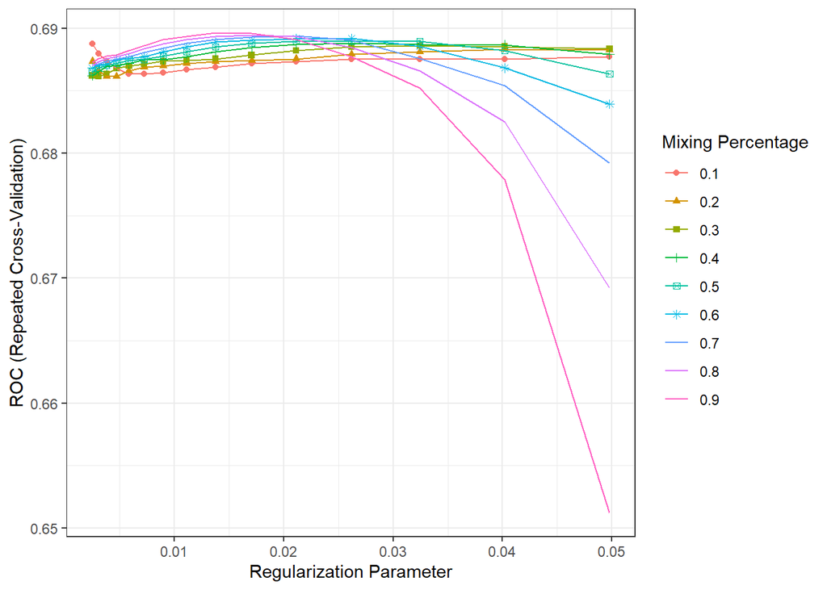

```r
ggplot(mod_2_tune) + theme_bw()
```

```r
mod_2_tune$bestTune
```

```
##     alpha     lambda
## 129   0.9 0.01376379
```

```r
coef(mod_2_tune$finalModel) %>% rownames()
```

```
##   [1] "(Intercept)"          "xAA2"                 "xBB2"
##   [4] "xBB3"                 "xBB4"                 "response_1"
##   [7] "x07"                  "x08"                  "x09"
##  [10] "x10"                  "x11"                  "xAA2:xBB2"
##  [13] "xAA2:xBB3"            "xAA2:xBB4"            "xAA2:response_1"
##  [16] "xAA2:x07"             "xAA2:x08"             "xAA2:x09"
##  [19] "xAA2:x10"             "xAA2:x11"             "xBB2:response_1"
##  [22] "xBB3:response_1"      "xBB4:response_1"      "xBB2:x07"
##  [25] "xBB3:x07"             "xBB4:x07"             "xBB2:x08"
##  [28] "xBB3:x08"             "xBB4:x08"             "xBB2:x09"
##  [31] "xBB3:x09"             "xBB4:x09"             "xBB2:x10"
##  [34] "xBB3:x10"             "xBB4:x10"             "xBB2:x11"
##  [37] "xBB3:x11"             "xBB4:x11"             "response_1:x07"
##  [40] "response_1:x08"       "response_1:x09"       "response_1:x10"
##  [43] "response_1:x11"       "x07:x08"              "x07:x09"
```

[output cut: 36 more lines]

```r
coef(mod_2_tune$finalModel, s = mod_2_tune$bestTune$lambda) %>%
  as.matrix() %>%
  as.data.frame() %>%
  tibble::rownames_to_column("coef_name") %>%
  tibble::as_tibble() %>%
  purrr::set_names(c("coef_name", "coef_value")) %>%
  filter(coef_value != 0) %>%
  nrow()
```

```
## [1] 29
```

```r
confusionMatrix.train(mod_2_tune)
```

```
## Cross-Validated (5 fold, repeated 3 times) Confusion Matrix
##
## (entries are percentual average cell counts across resamples)
##
##           Reference
## Prediction Fail Pass
##       Fail 26.3 13.6
##       Pass 22.6 37.4
##
##  Accuracy (average) : 0.6377
```

Train and tune Naive Bayes:

```r
set.seed(2001)
mod_3 <- train(outcome_2 ~ .,
               data = step_2_b_df,
               method = 'nb',
               metric = my_metric,
               preProcess = c("center", "scale"),
               trControl = my_ctrl)
mod_3
```

```
## Naive Bayes
##
## 2013 samples
##    8 predictor
##    2 classes: 'Fail', 'Pass'
##
## Pre-processing: centered (10), scaled (10)
## Resampling: Cross-Validated (5 fold, repeated 3 times)
## Summary of sample sizes: 1611, 1610, 1611, 1610, 1610, 1611, ...
## Resampling results across tuning parameters:
##
##   usekernel  ROC        Sens       Spec
##   FALSE      0.7295687  0.5962775  0.7432015
##    TRUE      0.7709019  0.6040609  0.7957329
##
## Tuning parameter 'fL' was held constant at a value of 0
## Tuning
##  parameter 'adjust' was held constant at a value of 1
## ROC was used to select the optimal model using the largest value.
## The final values used for the model were fL = 0, usekernel = TRUE and adjust
##  = 1.
```

```r
confusionMatrix.train(mod_3)
```

```
## Cross-Validated (5 fold, repeated 3 times) Confusion Matrix
##
## (entries are percentual average cell counts across resamples)
##
##           Reference
## Prediction Fail Pass
##       Fail 29.6 10.4
##       Pass 19.4 40.6
##
##  Accuracy (average) : 0.7019
```

### Non-linear models

Train and tune Neural network:

```r
set.seed(2001)
mod_4_default <- train(outcome_2 ~ (.),
               data = step_2_b_df,
               method = 'nnet',
               metric = my_metric,
               preProc = c("center", "scale"),
               trControl = my_ctrl,
               trace = FALSE)
mod_4_default
```

```
## Neural Network
##
## 2013 samples
##    8 predictor
##    2 classes: 'Fail', 'Pass'
##
## Pre-processing: centered (10), scaled (10)
## Resampling: Cross-Validated (5 fold, repeated 3 times)
## Summary of sample sizes: 1611, 1610, 1611, 1610, 1610, 1611, ...
## Resampling results across tuning parameters:
##
##   size  decay  ROC        Sens       Spec
##   1     0e+00  0.6093305  0.3417936  0.8657826
##   1     1e-04  0.6155774  0.3810491  0.8323925
##   1     1e-01  0.6134006  0.4101523  0.8100624
##   3     0e+00  0.7316179  0.6629442  0.7016181
##   3     1e-04  0.7352167  0.6534687  0.7214082
##   3     1e-01  0.7744342  0.6961083  0.7367495
##   5     0e+00  0.7475236  0.6930626  0.6884095
##   5     1e-04  0.7552162  0.7021997  0.6909922
##   5     1e-01  0.7997131  0.7299492  0.7451527
##
## ROC was used to select the optimal model using the largest value.
## The final values used for the model were size = 5 and decay = 0.1.
```

```r
nnet_grid <- expand.grid(size = c(3, 5, 10, 15),
                         decay = exp(seq(-6, 3, length.out = 31)))

set.seed(2001)

mod_4_tune <- train(outcome_2 ~ (.),
               data = step_2_b_df,
               method = 'nnet',
               tuneGrid = nnet_grid,
               preProc = c("center", "scale"),
               metric = my_metric,
               trControl = my_ctrl,
               trace = FALSE)
mod_4_tune
```

```
## Neural Network
##
## 2013 samples
##    8 predictor
##    2 classes: 'Fail', 'Pass'
##
## Pre-processing: centered (10), scaled (10)
## Resampling: Cross-Validated (5 fold, repeated 3 times)
## Summary of sample sizes: 1611, 1610, 1611, 1610, 1610, 1611, ...
## Resampling results across tuning parameters:
##
##   size  decay         ROC        Sens       Spec
##    3     0.002478752  0.7439575  0.6734349  0.7107475
##    3     0.003345965  0.7560569  0.6619289  0.7360818
##    3     0.004516581  0.7555039  0.6568528  0.7250328
```

[output cut: 124 more lines]

```r
mod_4_tune$bestTune
```

```
##    size     decay
## 49    5 0.4065697
```

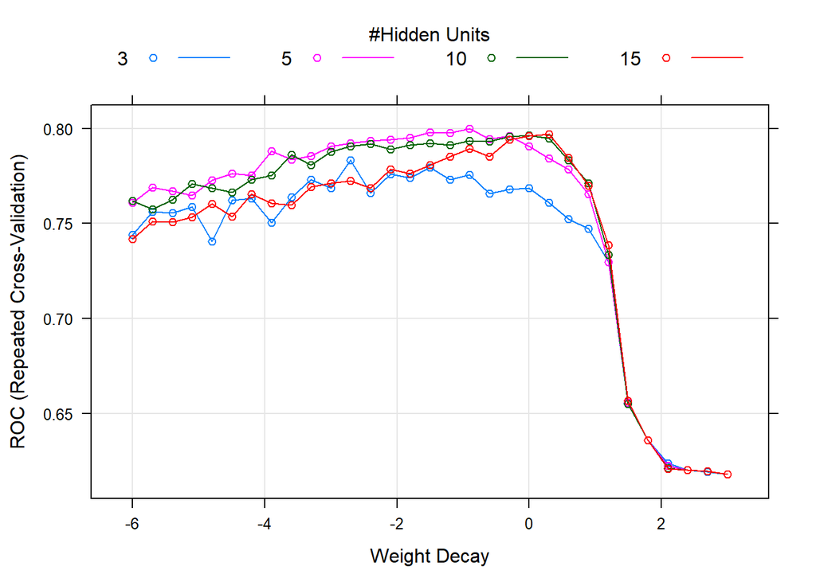

```r
plot(mod_4_tune, xTrans = log)
```

```r
confusionMatrix.train(mod_4_tune)
```

```
## Cross-Validated (5 fold, repeated 3 times) Confusion Matrix
##
## (entries are percentual average cell counts across resamples)
##
##           Reference
## Prediction Fail Pass
##       Fail 35.2 13.1
##       Pass 13.7 38.0
##
##  Accuracy (average) : 0.7316
```

```r
library(NeuralNetTools)
```

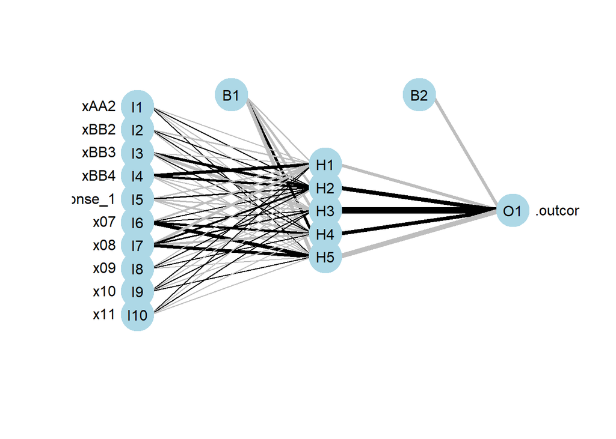

```r
plotnet(mod_4_tune$finalModel)
```

Train and tune Random Forest:

```r
set.seed(2001)
mod_5 <- train(outcome_2 ~ .,
                       data = step_2_b_df,
                       method = "rf",
                       metric = my_metric,
                       trControl = my_ctrl,
                       importance = TRUE)
mod_5
```

```
## Random Forest
##
## 2013 samples
##    8 predictor
##    2 classes: 'Fail', 'Pass'
##
## No pre-processing
## Resampling: Cross-Validated (5 fold, repeated 3 times)
## Summary of sample sizes: 1611, 1610, 1611, 1610, 1610, 1611, ...
## Resampling results across tuning parameters:
##
##   mtry  ROC        Sens       Spec
##    2    0.7901874  0.7170897  0.7331692
##    6    0.8002217  0.7455161  0.7247265
##   10    0.7980307  0.7407783  0.7218107
##
## ROC was used to select the optimal model using the largest value.
## The final value used for the model was mtry = 6.
```

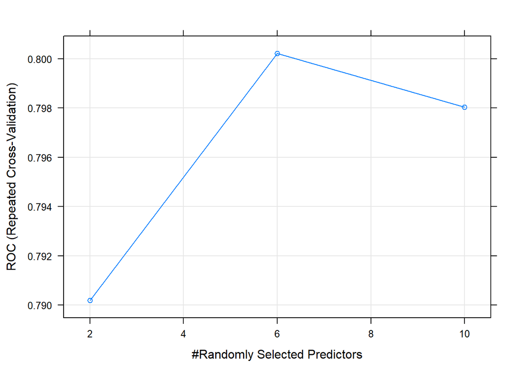

```r
plot(mod_5)
```

```r
confusionMatrix.train(mod_5)
```

```
## Cross-Validated (5 fold, repeated 3 times) Confusion Matrix
##
## (entries are percentual average cell counts across resamples)
##
##           Reference
## Prediction Fail Pass
##       Fail 36.5 14.1
##       Pass 12.5 37.0
##
##  Accuracy (average) : 0.7349
```

Train and tune boosted tree model with `xgboost`:

```r
set.seed(2001)
mod_6 <- train(outcome_2 ~ .,
                       data = step_2_b_df,
                       method = "xgbTree",
                       metric = my_metric,
                       trControl = my_ctrl,
                       importance = TRUE)
```

[output not shown]

[output cut: 4271 more lines]

[output not shown]

```r
mod_6
```

```
## eXtreme Gradient Boosting
##
## 2013 samples
##    8 predictor
##    2 classes: 'Fail', 'Pass'
##
## No pre-processing
## Resampling: Cross-Validated (5 fold, repeated 3 times)
## Summary of sample sizes: 1611, 1610, 1611, 1610, 1610, 1611, ...
## Resampling results across tuning parameters:
##
##   eta  max_depth  colsample_bytree  subsample  nrounds  ROC        Sens
##   0.3  1          0.6               0.50        50      0.7755610  0.6453469
##   0.3  1          0.6               0.50       100      0.7769765  0.6642978
##   0.3  1          0.6               0.50       150      0.7752418  0.6686971
##   0.3  1          0.6               0.75        50      0.7788288  0.6504230
##   0.3  1          0.6               0.75       100      0.7785888  0.6582064
##   0.3  1          0.6               0.75       150      0.7768964  0.6642978
##   0.3  1          0.6               1.00        50      0.7776328  0.6294416
##   0.3  1          0.6               1.00       100      0.7794236  0.6419628
##   0.3  1          0.6               1.00       150      0.7781939  0.6467005
##   0.3  1          0.8               0.50        50      0.7765920  0.6538071
##   0.3  1          0.8               0.50       100      0.7778037  0.6707276
##   0.3  1          0.8               0.50       150      0.7744811  0.6683587
##   0.3  1          0.8               0.75        50      0.7783013  0.6487310
##   0.3  1          0.8               0.75       100      0.7802868  0.6582064
##   0.3  1          0.8               0.75       150      0.7766830  0.6626058
##   0.3  1          0.8               1.00        50      0.7778131  0.6321489
##   0.3  1          0.8               1.00       100      0.7799453  0.6409475
##   0.3  1          0.8               1.00       150      0.7785287  0.6507614
##   0.3  2          0.6               0.50        50      0.7878264  0.6862944
##   0.3  2          0.6               0.50       100      0.7825153  0.6876481
##   0.3  2          0.6               0.50       150      0.7817293  0.6873096
##   0.3  2          0.6               0.75        50      0.7936724  0.6903553
##   0.3  2          0.6               0.75       100      0.7919738  0.6930626
##   0.3  2          0.6               0.75       150      0.7843309  0.6856176
##   0.3  2          0.6               1.00        50      0.7938666  0.6774958
##   0.3  2          0.6               1.00       100      0.7915250  0.6818951
##   0.3  2          0.6               1.00       150      0.7891962  0.6876481
##   0.3  2          0.8               0.50        50      0.7918164  0.6849408
```

[output cut: 182 more lines]

```
##   0.7179099
##   0.7474071
##   0.7357566
##   0.7302407
##   0.7639656
##   0.7542237
##   0.7461362
##
## Tuning parameter 'gamma' was held constant at a value of 0
## Tuning
##  parameter 'min_child_weight' was held constant at a value of 1
## ROC was used to select the optimal model using the largest value.
## The final values used for the model were nrounds = 50, max_depth = 3, eta
##  = 0.3, gamma = 0, colsample_bytree = 0.8, min_child_weight = 1 and subsample
##  = 1.
```

```r
mod_6$bestTune
```

```
##    nrounds max_depth eta gamma colsample_bytree min_child_weight subsample
## 52      50         3 0.3     0              0.8                1         1
```

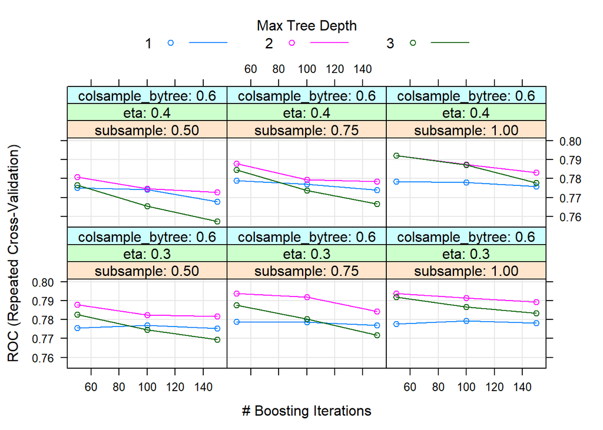

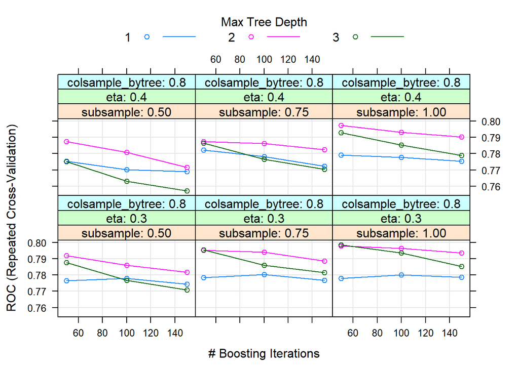

```r
plot(mod_6)
```

```r
confusionMatrix.train(mod_6)
```

```
## Cross-Validated (5 fold, repeated 3 times) Confusion Matrix
##
## (entries are percentual average cell counts across resamples)
##
##           Reference
## Prediction Fail Pass
##       Fail 34.3 12.3
##       Pass 14.7 38.8
##
##  Accuracy (average) : 0.7309
```

Train and tune SVM:

```r
set.seed(2001)
mod_7 <- train(outcome_2 ~ .,
               data = step_2_b_df,
               method = "svmRadial",
               metric = my_metric,
               preProcess = c("center", "scale"),
               trControl = my_ctrl)
mod_7
```

```
## Support Vector Machines with Radial Basis Function Kernel
##
## 2013 samples
##    8 predictor
##    2 classes: 'Fail', 'Pass'
##
## Pre-processing: centered (10), scaled (10)
## Resampling: Cross-Validated (5 fold, repeated 3 times)
## Summary of sample sizes: 1611, 1610, 1611, 1610, 1610, 1611, ...
## Resampling results across tuning parameters:
##
##   C     ROC        Sens       Spec
##   0.25  0.7601730  0.6554992  0.7328329
##   0.50  0.7711215  0.6642978  0.7500103
##   1.00  0.7762756  0.6683587  0.7519520
##
## Tuning parameter 'sigma' was held constant at a value of 0.07181455
## ROC was used to select the optimal model using the largest value.
## The final values used for the model were sigma = 0.07181455 and C = 1.
```

```r
confusionMatrix.train(mod_7)
```

```
## Cross-Validated (5 fold, repeated 3 times) Confusion Matrix
##
## (entries are percentual average cell counts across resamples)
##
##           Reference
## Prediction Fail Pass
##       Fail 32.7 12.7
##       Pass 16.2 38.4
##
##  Accuracy (average) : 0.711
```

Compare all models:

```r
regression_results = resamples(list(GLM = mod_1,
                                    GLMNET_trips = mod_2_tune,
                                    NB = mod_3,
                                    NNET = mod_4_tune,
                                    RF = mod_5,
                                    XGB = mod_6,
                                    SVM = mod_7))
```

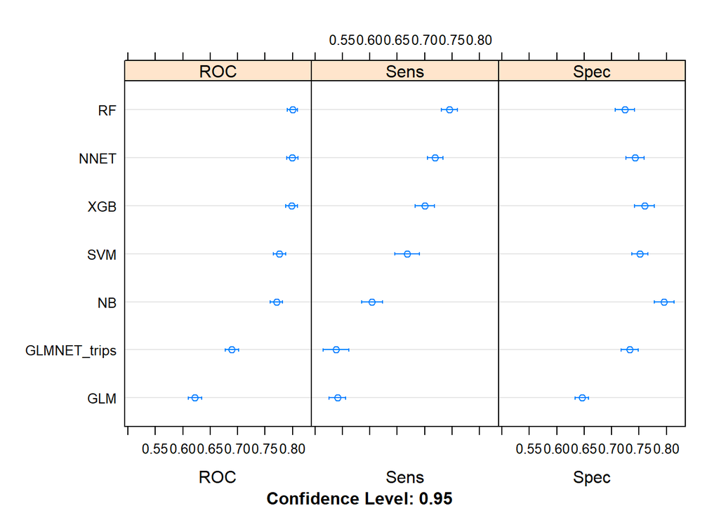

```r
dotplot(regression_results)
```

Let’s now visualize the hold-out set predictions.

```r
model_pred_results <- mod_5$pred %>% tibble::as_tibble() %>%
  filter(mtry == mod_5$bestTune$mtry) %>%
  select(pred, obs, Fail, Pass, rowIndex, Resample) %>%
  mutate(model_name = "RF") %>%
  bind_rows(mod_2_tune$pred %>% tibble::as_tibble() %>%
              filter(alpha == mod_2_tune$bestTune$alpha,
                     lambda == mod_2_tune$bestTune$lambda) %>%
              select(pred, obs, Fail, Pass, rowIndex, Resample) %>%
              mutate(model_name = "GLMNET_trips")) %>%
  bind_rows(mod_4_tune$pred %>% tibble::as_tibble() %>%
              filter(size == mod_4_tune$bestTune$size,
                     decay == mod_4_tune$bestTune$decay) %>%
              select(pred, obs, Fail, Pass, rowIndex, Resample) %>%
              mutate(model_name = "NNET")) %>%
  bind_rows(mod_6$pred %>% tibble::as_tibble() %>%
              filter(nrounds == mod_6$bestTune$nrounds,
                     max_depth == mod_6$bestTune$max_depth,
                     eta == mod_6$bestTune$eta,
                     gamma == mod_6$bestTune$gamma,
                     colsample_bytree == mod_6$bestTune$colsample_bytree,
                     min_child_weight == mod_6$bestTune$min_child_weight,
                     subsample == mod_6$bestTune$subsample) %>%
              select(pred, obs, Fail, Pass, rowIndex, Resample) %>%
              mutate(model_name = "XGB"))
```

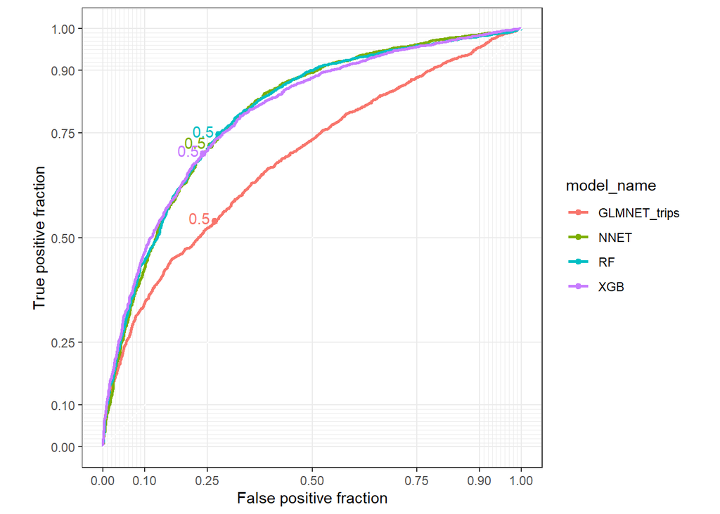

```r
library(plotROC)
model_pred_results %>%
  ggplot(mapping = aes(m = Fail,
                       d = ifelse(obs == "Fail",
                                  1,
                                  0))) +
  geom_roc(cutoffs.at = 0.5, mapping = aes(color = model_name)) +
  coord_equal() +
  style_roc()
```

```r
mod_5 %>% readr::write_rds("best_b_model.rds")
```